# **Tema:** A Relação entre a Independência do Banco Central e a Potência da Política Monetária

Professores:** Juliana Inhasz Sérgio Ricardo Martins Paulo Jose Mencacci Costa (Prof. Auxiliar)

Integrantes:** Caio Santa Rosa Christovam – caiosrc@al.insper.edu.br Érika Kaori Fuzisaka – erikakf1@al.insper.edu.br Hicham Munir Tayfour – hichamt@al.insper.edu.br Lucas Batista Ferreira – lucasbf1@al.insper.edu.br Maria Antonia Pereira Guimarães – mariaapg1@al.insper.edu.br Maria Eduarda Marques Pereira – mariaemp@al.insper.edu.br Maria Morais Garcia Leal – mariamgl@al.insper.edu.br

São Paulo – Fevereiro/Maio de 2025

# 1 🔍 Hipótese de Pesquisa

Este estudo busca avaliar empiricamente a seguinte hipótese:

> **Hipótese**: Quanto maior o grau de independência do Banco Central, maior será a potência da política monetária no controle inflacionário.

Mais especificamente, assume-se que bancos centrais com maior autonomia institucional possuem maior credibilidade e capacidade de ancorar expectativas, o que se reflete em uma resposta mais efetiva da inflação à política monetária.

Para testar essa hipótese, será conduzida uma análise empírica baseada em dados internacionais, com foco na relação entre:

- O **grau de independência do Banco Central** (medido por um índice padronizado ou por classificação categórica), e
- A **potência da política monetária**, avaliada por meio da resposta da inflação a variações na taxa de juros real.

Modelos econométricos e análises descritivas complementares serão utilizados para investigar essa relação ao longo do tempo e entre diferentes grupos de países (por regime monetário e instituições).

# 2 ▶️ Reprodução

Este trabalho poderá ser encontrado no GitHub [PEE 2025.1 - Grupo 7](https://github.com/Hic-Tayfour/R/tree/main/College%20Works/PEE%202025.1). A estrutura do repositório está organizada para garantir reprodutibilidade total da análise.

## 2.1 📁 Estrutura de Arquivos

A pasta `Data` contém 5 arquivos `.xlsx` fundamentais:

1. **CBIDta.xlsx**: Dados sobre independência dos bancos centrais (CBIE) — Romelli (2022, 2024) — cobrindo 155 países entre 1923 e 2023.
2. **InflationForecast(FMI).xlsx**: Projeções de inflação do FMI.
3. **rate_macrobond.xlsx**: Taxas de juros nominais coletadas via Macrobond.
4. **target(eikon).xlsx**: Metas de inflação obtidas via Eikon.
5. **target(macrobond).xlsx**: Metas de inflação obtidas via Macrobond (prioritárias para países da Zona do Euro).

Além disso, os seguintes scripts e documentos estão incluídos:

- **PEE.R**: Código principal com etapas de importação, limpeza, cálculo e estimativas.
- **PEE.Rmd**: Documento R Markdown com a estrutura analítica e narrativa do trabalho.
- **Base de Dados.md**: Script para download automatizado dos dados via GitHub.
- **README.md**: Descrição completa do projeto, metodologia e orientações de execução.

# 3 ⚙️ Configuração do Ambiente

```r
knitr::opts_chunk$set(fig.width=15, fig.height=10)
```

# 4 📦 Carregando Pacotes

```r
# 📊 Manipulação e Visualização de Dados
library(tidyverse)
library(dplyr)
library(ggplot2)
library(ggthemes)
library(ggtext)
library(patchwork)
library(gridExtra)
library(CGPfunctions)
library(scales)
library(viridis)
library(ggstream)
library(gganimate)
library(plotly)
library(ggeffects)
library(ggrepel)
library(glue)
library(stringr)

# 📈 Análise de Séries Temporais e Dados Econômicos
library(tidyquant)
library(WDI)
library(imf.data)
library(seasonal)
library(mFilter)
library(zoo)
library(sidrar)
library(rugarch)

# 📉 Modelagem e Econometria
library(plm)
library(broom)
library(fixest)

# 🌍 Geodados e Mapas
library(rnaturalearth)
library(sf)
library(countrycode)

# 📥 Leitura e Organização de Dados
library(readxl)
library(labelled)

# 📑 Tabelas Profissionais
library(gt)
library(gtExtras)
library(stargazer)
```

# 5 📃 Importando e Ajustando as Bases de Dados

Nesta seção, realizamos a importação e integração das principais bases de dados macroeconômicos utilizadas no estudo. As informações são obtidas a partir de fontes confiáveis, como o Banco Mundial (WDI), o FMI (IFS), e arquivos auxiliares em Excel contendo o índice de independência dos Bancos Centrais e expectativas de inflação. O objetivo é construir uma base padronizada, consistente e apropriada para a análise empírica.

## 5.1 📥 Download de Indicadores do Banco Mundial

```r
# Consulta aos indicadores disponíveis no WDI
indicadores <- WDIsearch()

# Lista de agrupamentos macroeconômicos para exclusão
agrupamentos <- c(
  "Africa Eastern and Southern", "Africa Western and Central", "Arab World",
  "Early-demographic dividend", "East Asia & Pacific",
  "East Asia & Pacific (excluding high income)",
  "East Asia & Pacific (IDA & IBRD countries)", "Euro area",
  "Europe & Central Asia", "Europe & Central Asia (excluding high income)",
  "Europe & Central Asia (IDA & IBRD countries)", "European Union",
  "Fragile and conflict affected situations", "Heavily indebted poor countries (HIPC)",
  "High income", "IBRD only", "IDA & IBRD total", "IDA blend", "IDA only",
  "IDA total", "Late-demographic dividend", "Latin America & Caribbean",
  "Latin America & Caribbean (excluding high income)",
  "Latin America & the Caribbean (IDA & IBRD countries)",
  "Least developed countries: UN classification", "Low & middle income",
  "Low income", "Lower middle income", "Middle East & North Africa",
  "Middle East & North Africa (excluding high income)",
  "Middle East & North Africa (IDA & IBRD countries)", "Middle income",
  "Not classified", "OECD members", "Other small states",
  "Pacific island small states", "Post-demographic dividend",
  "Pre-demographic dividend", "Small states", "South Asia",
  "South Asia (IDA & IBRD)", "Sub-Saharan Africa",
  "Sub-Saharan Africa (excluding high income)",
  "Sub-Saharan Africa (IDA & IBRD countries)", "Upper middle income", "World"
)

euro_area <- tibble(country = c(
  "Austria", "Belgium", "Bulgaria", "Croatia", "Republic of Cyprus",
  "Czech Republic", "Denmark", "Estonia", "Finland", "France", "Germany",
  "Greece", "Hungary", "Ireland", "Italy", "Latvia", "Lithuania",
  "Luxembourg", "Malta", "Netherlands", "Poland", "Portugal", "Romania",
  "Slovakia", "Slovenia", "Spain", "Sweden"
)) %>%
  mutate(
    iso3c = countrycode(country, "country.name", "iso3c"),
    iso2c = countrycode(country, "country.name", "iso2c")
  )
```

## 5.2 📊 Importação e Tratamento das Variáveis Econômicas

```r
# PIB real (constante, US$ 2015)

gdp <- WDI(
  country = "all",
  indicator = "NY.GDP.MKTP.KD",
  start = 1960,
  end = NULL,
  extra = TRUE
) %>%
  filter(!country %in% agrupamentos) %>%
  select(country, iso2c, iso3c, year, NY.GDP.MKTP.KD) %>%
  rename(pib = NY.GDP.MKTP.KD) %>%
  arrange(country, year)

# Inflação

cpi <- WDI(
  country = "all",
  indicator = "FP.CPI.TOTL.ZG",
  start = 1960,
  end = NULL,
  extra = TRUE
) %>%
  filter(!country %in% agrupamentos) %>%
  select(country, iso2c, iso3c, year, FP.CPI.TOTL.ZG) %>%
  rename(inflation = FP.CPI.TOTL.ZG) %>%
  arrange(country, year)

# Dívida governamental (% do PIB)

debt <- WDI(
  country = "all",
  indicator = "GC.DOD.TOTL.GD.ZS",
  start = 1960,
  end = NULL,
  extra = TRUE
) %>%
  filter(!country %in% agrupamentos) %>%
  select(country, iso2c, iso3c, year, GC.DOD.TOTL.GD.ZS) %>%
  rename(divida = GC.DOD.TOTL.GD.ZS) %>%
  arrange(country, year)
```

## 5.3 📁 Bases Complementares: Independência do BC e Expectativas

```r
# Índice de independência do Banco Central (base CBIE)

cbi <- read_xlsx("CBIDta.xlsx", sheet = "Data") %>%
  select(country, iso_a3, year, cbie_index, cbie_policy, cbie_policy_q1
) %>%
  mutate(year = as.numeric(year)) %>%
  arrange(country, year) %>%
  rename(iso3c = iso_a3) %>%
  select(country, iso3c, year, cbie_index, cbie_policy, cbie_policy_q1)

# Expectativas de inflação (FMI)

inf_for <- read_xlsx("InflationForecast(FMI).xlsx") %>%
  select(Country, Code, Year, `Inflation forecast`) %>%
  rename(
    inflation_forecast = `Inflation forecast`,
    country = Country,
    code = Code,
    year = Year
  ) %>%
  mutate(iso3c = countrycode(
    sourcevar = country,
    origin = "country.name",
    destination = "iso3c"
  ))

# Metas de Inflação (MacroBond)

target_panel_bond <- read_excel("target(macrobond).xlsx", sheet = "Sheet1") %>%
  rename(date = "...1") %>%
  mutate(date = as.Date(date, origin = "1899-12-30")) %>%
  mutate(year = year(date)) %>%
  group_by(year) %>%
  filter(date == max(date)) %>%
  ungroup() %>%
  pivot_longer(
    cols = -c(date, year),
    names_to = "full_country_name",
    values_to = "target"
  ) %>%
  mutate(country = gsub("^([^,]+),.*", "\\1", full_country_name)) %>%
  select(country, year, target) %>%
  filter(!is.na(target))%>%
  arrange(country, year)

# Metas de Inflação (Eikon)

target_panel_eikon <- read_excel("target(eikon).xlsx", sheet = "valores") %>%
  mutate(country = str_to_title(GEOGN)) %>%
  mutate(across(matches("^\\d+$"), as.character)) %>%
  pivot_longer(
    cols = matches("^\\d+$"),
    names_to = "date_num",
    values_to = "target"
  ) %>%
  mutate(
    target = na_if(target, "NA"),
    date = as.Date(as.numeric(date_num), origin = "1899-12-30"),
    year = year(date),
    target = as.numeric(target)
  ) %>%
  select(country, year, target) %>%
  arrange(country, year)

# Juntando as duas bases de metas de inflação

target <- target_panel_eikon %>%
  full_join(target_panel_bond, by = c("country", "year"), suffix = c("_eikon", "_bond")) %>%
  mutate(
    target = coalesce(target_eikon, target_bond)
  ) %>%
  select(country, year, target) %>%
  bind_rows(
    target_panel_bond %>%
      filter(country == "Euro Area", year >= 2000, year <= 2023) %>%
      select(year, target) %>%
      crossing(country = euro_area$country)
  ) %>%
  filter(year >= 2000, year <= 2023) %>%
  distinct(country, year, .keep_all = TRUE) %>%
  mutate(
    iso3c = case_when(
      country == "Euro Area" ~ "EMU",
      TRUE ~ countrycode(country, "country.name", "iso3c")
    )
  ) %>%
  arrange(country, year)
```

## 5.4 💰 Taxa de Juros de Política Monetária (FMI - IFS)

```r
# Importação da base IFS do FMI

ifs <- load_datasets("IFS")

# Seleção da série de taxa de juros

data_wide_ifs <- ifs$get_series(
  freq         = "A",
  ref_area     = NULL,
  indicator    = "FPOLM_PA",
  start_period = "1960",
  end_period   = "2025"
)

# Transformação da base

rate <- data_wide_ifs %>%
  pivot_longer(cols = -TIME_PERIOD,
               names_to = "col_indicator",
               values_to = "taxa_juros") %>%
  mutate(
    iso2c = sub("^A\\.(.*?)\\.FPOLM_PA$", "\\1", col_indicator),
    year  = as.numeric(TIME_PERIOD)
  ) %>%
  mutate(iso2c = case_when(iso2c %in% c("7A", "U2") ~ "EA", TRUE ~ iso2c)) %>%
  mutate(
    iso3c   = countrycode(iso2c, origin = "iso2c", destination = "iso3c"),
    country = countrycode(iso2c, origin = "iso2c", destination = "country.name")
  ) %>%
  filter(!is.na(country)) %>%
  select(country, iso2c, iso3c, year, taxa_juros)

# Dados de taxa de juros do Macrobond

rate_macrobond <- read_excel("rate_macrobond.xlsx") %>%
  rename(date = ...1) %>%
  pivot_longer(
    cols = -date,
    names_to = "full_country_name",
    values_to = "taxa_juros"
  ) %>%
  mutate(
    country = str_extract(full_country_name, "^[^,]+"),
    taxa_juros = as.numeric(taxa_juros),
    year = year(date)
  ) %>%
  filter(!is.na(taxa_juros)) %>%
  group_by(country, year) %>%
  filter(date == max(date)) %>%
  ungroup() %>%
  select(country, year, taxa_juros) %>%
  filter(year <= 2023) %>%
  arrange(country, year)

# Juntando as duas bases de taxa de juros

rate <- rate %>%
  mutate(taxa_juros = as.numeric(taxa_juros)) %>%
  filter(!country %in% euro_area$country) %>%
  bind_rows(
    rate_macrobond %>%
      semi_join(euro_area, by = "country")
  ) %>%
  mutate(
    iso2c = countrycode(country, origin = "country.name", destination = "iso2c"),
    iso3c = countrycode(country, origin = "country.name", destination = "iso3c")
  ) %>%
  arrange(country, year)
```

## 5.5 Base de Dados de Situação Fiscal

```r
# Importação da base IFS do FMI

data_wide_fm <- load_datasets("FM")$get_series(
  freq        = "A",
  ref_area    = NULL,
  indicator   = "GGXONLB_G01_GDP_PT",
  start_period = "1990",
  end_period   = "2025"
)

# Seleção da série de taxa de juros e Transformação da base

capb <- data_wide_fm %>%
  pivot_longer(-TIME_PERIOD,
               names_to  = "col_indicator",
               values_to = "capb") %>%
  mutate(
    iso2c = sub("^A\\.([^.]*)\\..*$", "\\1", col_indicator),
    iso2c = if_else(iso2c %in% c("7A","U2"), "EA", iso2c),
    year  = as.integer(TIME_PERIOD),
    capb  = as.numeric(capb)
  ) %>%
  filter(grepl("^[A-Z]{2}$", iso2c)) %>%
  mutate(
    iso3c = case_when(
      iso2c == "EA" ~ "EMU",
      iso2c == "XK" ~ "XKX",
      TRUE ~ countrycode(iso2c, "iso2c", "iso3c", warn = FALSE)
    ),
    country = case_when(
      iso2c == "EA" ~ "Euro Area",
      iso2c == "XK" ~ "Kosovo",
      TRUE ~ countrycode(iso2c, "iso2c", "country.name", warn = FALSE)
    )
  ) %>%
  arrange(country, year) %>%
  group_by(country) %>%
  mutate(impulso_fiscal = -(capb - dplyr::lag(capb, order_by = year))) %>%
  ungroup() %>%
  select(country, iso2c, iso3c, year, capb, impulso_fiscal) %>%
  semi_join(
    target %>% filter(year >= 2000, year <= 2023) %>% distinct(iso3c, year),
    by = c("iso3c", "year")
  ) %>%
  mutate(iso2c_original = iso2c) %>%
  select(-iso2c) %>%
  rename(iso2c = iso2c_original)

# Juntando a base de situação fiscal com a base de dívida

debt <- debt %>%
  left_join(
    capb %>%
      select(iso3c, year, impulso_fiscal) %>%
      distinct(),
    by = c("iso3c", "year")
  )
```

## 5.6 Base de dados “Própria”

```r
acemoglu_classification <- data.frame(
  Pais = c("Argentina", "Australia", "Austria", "Belgium", "Bolivia", "Brazil", "Canada",
           "Chile", "China", "Colombia", "Costa Rica", "Denmark", "Dominican Republic",
           "Ecuador", "El Salvador", "Finland", "France", "Germany", "Greece", "Guatemala",
           "Guyana", "Honduras", "India", "Indonesia", "Ireland", "Israel", "Italy",
           "Japan", "South Korea","Malaysia", "Mexico", "Mongolia", "Nepal", "Netherlands",
           "New Zealand", "Nicaragua", "Norway", "Pakistan", "Paraguay", "Peru",
           "Philippines", "Portugal", "Qatar", "Singapore", "Spain", "Sweden",
           "Switzerland", "Turkey", "United Kingdom", "United States of America",
           "Uruguay", "Venezuela"),
  Classe = c("Medium", "High", "High", "Medium", "Medium", "Medium",
             "High", "Medium", "Medium", "Medium", "Medium", "High",
             "Medium", "Low", "Medium", "High", "Medium",
             "High", "Medium", "Low", "Medium", "Low", "Medium",
             "Low", "High", "Medium", "Medium", "Medium", "Medium", "Medium",
             "Medium", "Medium", "Medium", "High", "High", "Low",
             "High", "Low", "Low", "Medium", "Medium", "Medium",
             "Medium", "High", "Medium", "High", "High", "Medium",
             "High", "High", "Medium", "Low")
)
```

# 6 🧩 Integração das Bases e Construção da Base Final

```r
# Juntando todas as variáveis

data <- cbi %>%
  filter(year >= 2000, iso3c %in% (target %>% distinct(iso3c) %>% pull(iso3c))) %>%
  left_join(cpi %>% select(-country), by = c("iso3c", "year")) %>%
  left_join(debt %>% select(-country), by = c("iso3c", "year")) %>%
  left_join(gdp %>% select(-country), by = c("iso3c", "year")) %>%
  left_join(rate %>% select(-country), by = c("iso3c", "year")) %>%
  left_join(inf_for %>% select(-country), by = c("iso3c", "year")) %>%
  left_join(
    target %>% select(-country) %>% distinct(iso3c, year, .keep_all = TRUE),
    by = c("iso3c", "year")
  ) %>%
  select(-c(iso2c.y, iso2c.x.x, iso2c.y.y)) %>%
  rename(iso2c = iso2c.x) %>%
  group_by(country) %>%
  arrange(year) %>%
  mutate(
    taxa_juros = as.numeric(taxa_juros),
    pib_pot = hpfilter(pib, freq = 6.25)$trend,
    hiato_pct = ((pib - pib_pot) / pib_pot) * 100,
    real_rate = ((1 + taxa_juros) / (1 + inflation)) - 1,
    gap = (inflation - target),
    gap2 = abs(gap)
  ) %>%
  ungroup() %>%
  arrange(country, year) %>%
  select(
    country,
    iso3c,
    iso2c,
    year,
    pib,
    inflation,
    inflation_forecast,
    taxa_juros,
    cbie_index,
    cbie_policy,
    cbie_policy_q1,
    divida,
    impulso_fiscal,
    pib_pot,
    hiato_pct,
    real_rate,
    target,
    gap,
    gap2
  ) %>%
  set_variable_labels(
    pib = "GDP (constant 2015 US$)",
    inflation = "Inflação (%)",
    inflation_forecast = "Expectativa de Inflação (%)",
    taxa_juros = "Taxa de juros nominal (%)(BC)",
    cbie_index = "Índice de independência do Banco Central (%)",
    cbie_policy = "Índice de independência do Banco Central (política monetária)",
    cbie_policy_q1 = "Índice de independência do Banco Central (política monetária Q1)",
    divida = "Dívida governamental (% do PIB)",
    impulso_fiscal = "Impulso fiscal (p.p.)",
    pib_pot = "PIB potencial (filtro HP)",
    hiato_pct = "Hiato do produto (%)",
    real_rate = "Taxa de juros real (%)",
    target = "Meta de inflação (%)",
    gap = "Desvio da inflação em relação à meta (p.p.)",
    gap2 = "Desvio da inflação em relação à meta (p.p. absoluta)"
  ) %>%
  mutate(across(where(~ inherits(.x, "matrix")), as.numeric)) %>%
  group_by(country, year) %>%
  slice(1) %>%
  ungroup()
```

# 7 🔎 Visualização Inicial da Base Final

```r
# Visualização da base final

analisar_ocorrencias <- function(dados) {
  variaveis_banco <- c("pib", "inflation", "inflation_forecast", "target",
                       "taxa_juros", "divida", "impulso_fiscal","cbie_index")

  nomes_variaveis <- c("PIB", "Inflação", "Inflação Esperada", "Meta de Inflação",
                       "Taxa Nominal de Juros", "Dívida", "Impulso Fiscal" ,"CBI")

  total_paises <- n_distinct(dados$country)
  total_anos <- n_distinct(dados$year)
  total_esperado <- total_paises * total_anos

  qtd_observada <- numeric(length(variaveis_banco))
  paises_completos <- numeric(length(variaveis_banco))
  paises_incompletos <- numeric(length(variaveis_banco))
  paises_sem_dados <- numeric(length(variaveis_banco))

  for (i in seq_along(variaveis_banco)) {
    var <- variaveis_banco[i]

    qtd_observada[i] <- sum(!is.na(dados[[var]]))

    por_pais <- dados %>%
      group_by(country) %>%
      summarise(
        total_anos_esperados = n(),
        anos_com_dados = sum(!is.na(.data[[var]])),
        completo = anos_com_dados == total_anos_esperados,
        sem_dados = anos_com_dados == 0,
        .groups = "drop"
      )

    paises_completos[i] <- sum(por_pais$completo)
    paises_sem_dados[i] <- sum(por_pais$sem_dados)
    paises_incompletos[i] <- total_paises - paises_completos[i] - paises_sem_dados[i]
  }

  valores_linhas <- c(
    rep(total_esperado, length(variaveis_banco)),
    qtd_observada,
    paises_completos,
    paises_incompletos,
    paises_sem_dados
  )

  list(
    nomes_variaveis = nomes_variaveis,
    valores_linhas = valores_linhas
  )
}

criar_tabela_formatada_novo <- function(titulo, subtitulo, fonte, nomes_linhas, nomes_colunas, valores_linhas) {

  dados <- data.frame(
    Variável = nomes_linhas,
    matrix(valores_linhas, nrow = length(nomes_linhas), byrow = FALSE)
  )

  colnames(dados) <- c("Variável", nomes_colunas)

  gt(dados) %>%
    tab_header(
      title = md("**Base de Dados**"),
      subtitle = md(paste0("*", subtitulo, "*"))
    ) %>%
    tab_source_note(
      source_note = md(fonte)
    ) %>%
    tab_style(
      style = cell_text(weight = "bold"),
      locations = list(
        cells_column_labels(everything()),
        cells_body(columns = "Variável")
      )
    ) %>%
    cols_align(align = "center", columns = -1) %>%
    tab_options(table.font.size = 12) %>%
    fmt_number(columns = -1, decimals = 0, sep_mark = ".")
}


criar_tabela_ocorrencias_novo <- function(dados) {
  resultados <- analisar_ocorrencias(dados)

  titulo <- "Análise de Ocorrências nos Dados Macroeconômicos"
  subtitulo <- paste0("Base com ", n_distinct(dados$country), " países e ",
                      n_distinct(dados$year), " anos (", min(dados$year), "-", max(dados$year), ")")
  fonte <- "Fonte: WDI, IMF-IFS, TheGlobalEconomy, Eikon, MacroBond"

  nomes_linhas <- c("Qtd Total Esperada", "Qtd Total Observada",
                    "Qtd de Países com Todos os Dados",
                    "Qtd de Países Incompletos",
                    "Qtd de Países sem nenhum dado")

  nomes_colunas <- resultados$nomes_variaveis

  valores_linhas <- matrix(resultados$valores_linhas,
                           nrow = length(nomes_linhas),
                           byrow = TRUE)

  criar_tabela_formatada_novo(
    titulo = titulo,
    subtitulo = subtitulo,
    fonte = fonte,
    nomes_linhas = nomes_linhas,
    nomes_colunas = nomes_colunas,
    valores_linhas = valores_linhas
  )
}

tabela_ocorrencias_novo <- criar_tabela_ocorrencias_novo(data)
tabela_ocorrencias_novo
```

**Base de Dados**

*Base com 78 países e 24 anos (2000-2023)*

| Variável | PIB | Inflação | Inflação Esperada | Meta de Inflação | Taxa Nominal de Juros | Dívida | Impulso Fiscal | CBI |
| --- | --- | --- | --- | --- | --- | --- | --- | --- |
| Qtd Total Esperada | 1.872 | 1.872 | 1.872 | 1.872 | 1.872 | 1.872 | 1.872 | 1.872 |
| Qtd Total Observada | 1.869 | 1.843 | 1.863 | 1.516 | 1.419 | 923 | 1.745 | 1.869 |
| Qtd de Países com Todos os Dados | 78 | 76 | 73 | 40 | 39 | 14 | 57 | 78 |
| Qtd de Países Incompletos | 0 | 1 | 5 | 38 | 28 | 41 | 21 | 0 |
| Qtd de Países sem nenhum dado | 0 | 1 | 0 | 0 | 11 | 23 | 0 | 0 |

Fonte: WDI, IMF-IFS, TheGlobalEconomy, Eikon, MacroBond

# 8 🚯 Removendo Bases Auxiliares

```r
manter <- c("data",
            "acemoglu_classification")

rm(list = setdiff(ls(), manter))
```

# 9 📈 Análise Descritiva

## 9.1 📊 Gráfico de Cobertura de Dados

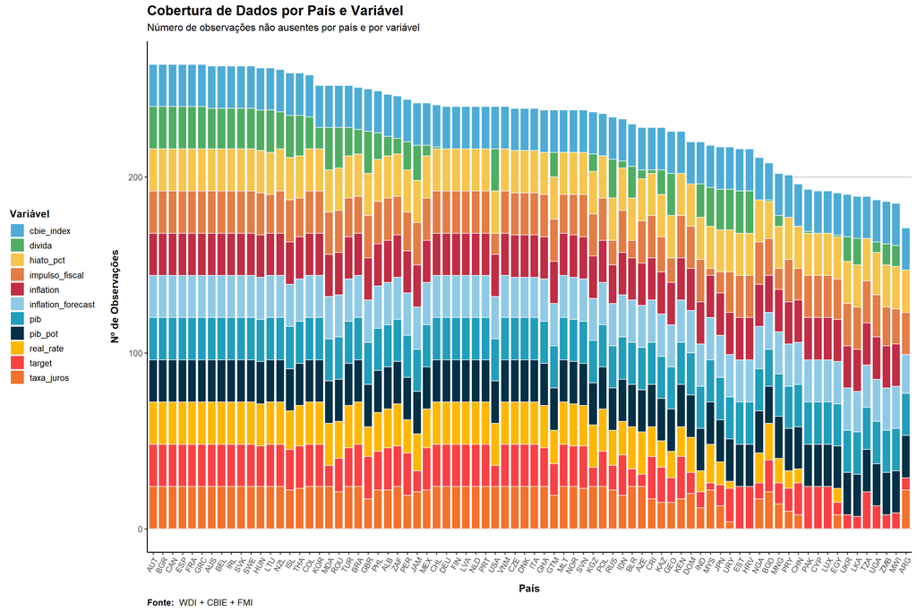

```r
data %>%
  mutate(across(
    c(pib,inflation,inflation_forecast,taxa_juros,cbie_index,divida,impulso_fiscal,pib_pot,hiato_pct,real_rate,target
    ),
    ~ as.numeric(.x)
  )) %>% select(iso3c,pib,inflation,inflation_forecast,taxa_juros,cbie_index,divida,impulso_fiscal,pib_pot,hiato_pct,real_rate,target
  ) %>%
  pivot_longer(cols = -iso3c,
               names_to = "variavel",
               values_to = "valor") %>%
  filter(!is.na(valor)) %>%
  count(iso3c, variavel, name = "n_obs") %>%
  ggplot(aes(
    x = fct_reorder(iso3c, -n_obs, .fun = sum),
    y = n_obs,
    fill = variavel
  )) +
  geom_bar(stat = "identity",
           color = "white",
           width = 0.85) +
  scale_fill_manual(
    values = c("#4DACD6","#4FAE62","#F6C54D","#E37D46","#C02D45","#8ecae6","#219ebc","#023047","#ffb703","#F94144","#F3722C"
    ),
    name = "Variável"
  ) +
  labs(
    title = "Cobertura de Dados por País e Variável",
    subtitle = "Número de observações não ausentes por país e por variável",
    x = "País",
    y = "Nº de Observações",
    caption = expression(bold("Fonte: ") ~ "WDI + CBIE + FMI")
  ) +
  theme_classic(base_size = 12) +
  theme(
    axis.text.x = element_text(
      angle = 60,
      hjust = 1,
      size = 9
    ),
    axis.title.x = element_text(face = "bold", margin = margin(t = 10)),
    axis.title.y = element_text(face = "bold", margin = margin(r = 10)),
    axis.text.y = element_text(size = 10),
    plot.title = element_text(face = "bold", size = 16, hjust = 0),
    plot.subtitle = element_text(
      size = 12,
      hjust = 0,
      margin = margin(b = 10)
    ),
    plot.caption = element_text(
      hjust = 0,
      size = 10,
      color = "black"
    ),
    legend.position = "left",
    legend.title = element_text(face = "bold"),
    legend.text = element_text(size = 10),
    panel.grid.major.y = element_line(color = "grey80"),
    panel.grid.major.x = element_blank()
  )
```

## 9.2 📊 Mapa de Cobertura de Dados

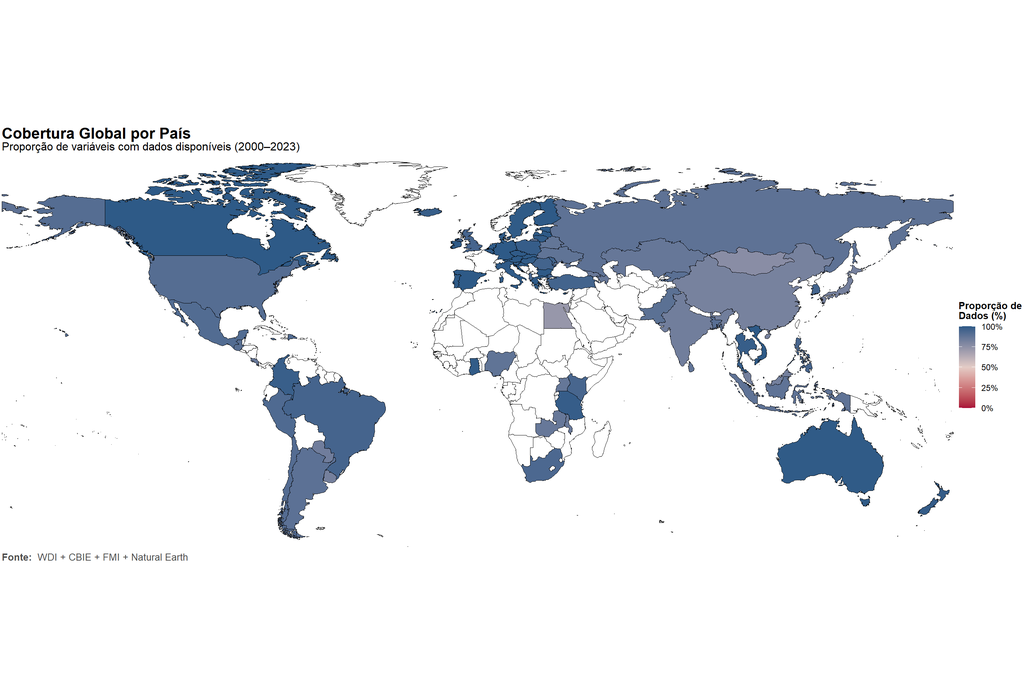

```r
world <- ne_countries(scale = "medium", returnclass = "sf") %>%
  filter(iso_a3 != "ATA")

world %>%
  left_join(
    data %>%
      select(iso3c, year,
             pib, inflation, inflation_forecast, taxa_juros, cbie_index,
             divida, impulso_fiscal, pib_pot, hiato_pct, real_rate, target) %>%
      pivot_longer(
        cols      = -c(iso3c, year),
        names_to  = "variavel",
        values_to = "valor"
      ) %>%
      filter(!is.na(valor)) %>%
      group_by(iso3c) %>%
      summarise(
        n_obs       = n(),
        n_var       = n_distinct(variavel),
        n_year      = n_distinct(year),
        total_ideal = n_var * n_year,
        prop_dados  = n_obs / total_ideal,
        .groups     = "drop"
      ),
    by = c("iso_a3" = "iso3c")
  ) %>%
  ggplot() +
  geom_sf(aes(fill = prop_dados), color = "black", size = .1) +
  scale_fill_gradient2(
    low       = paletteer::paletteer_c("ggthemes::Red-Blue Diverging", 30)[1],
    mid       = paletteer::paletteer_c("ggthemes::Red-Blue Diverging", 30)[15],
    high      = paletteer::paletteer_c("ggthemes::Red-Blue Diverging", 30)[30],
    midpoint  = 0.5,
    limits    = c(0, 1),
    na.value  = "white",
    name      = "Proporção de\nDados (%)",
    labels    = percent_format(accuracy = 1)
  ) +
  labs(
    title    = "Cobertura Global por País",
    subtitle = "Proporção de variáveis com dados disponíveis (2000–2023)",
    caption  = expression(bold("Fonte: ") ~ "WDI + CBIE + FMI + Natural Earth")
  ) +
  coord_sf(expand = FALSE) +
  theme_void(base_size = 13) +
  theme(
    plot.title      = element_text(face = "bold", size = 16, hjust = 0),
    plot.subtitle   = element_text(size = 12, hjust = 0, margin = margin(b = 10)),
    plot.caption    = element_text(size = 10, hjust = 0, color = "gray30"),
    legend.position = "right",
    legend.title    = element_text(face = "bold", size = 10),
    legend.text     = element_text(size = 9),
    plot.margin     = margin(2, 2, 2, 2)
  )
```

## 9.3 📊 Gráfico da Inflação por Grupo de Independência do Banco Central

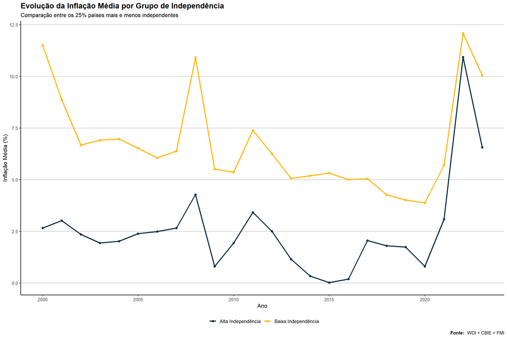

```r
data %>%
  filter(!is.na(inflation), !is.na(cbie_index)) %>%
  mutate(
    grupo_indep = if_else(
      cbie_index >= quantile(cbie_index, 0.75, na.rm = TRUE),
      "Alta Independência", "Baixa Independência"
    )
  ) %>%
  group_by(year, grupo_indep) %>%
  summarise(avg_infl = mean(inflation), .groups = "drop") %>%
  ggplot(aes(x = year, y = avg_infl, color = grupo_indep)) +
  geom_line(size = 1.2) +
  geom_point(size = 2) +
  scale_color_manual(
    values = c("Alta Independência" = "#023047", "Baixa Independência" = "#ffb703"),
    name = ""
  ) +
  labs(
    title    = "Evolução da Inflação Média por Grupo de Independência",
    subtitle = "Comparação entre os 25% países mais e menos independentes",
    x        = "Ano",
    y        = "Inflação Média (%)",
    caption  = expression(bold("Fonte: ") ~ "WDI + CBIE + FMI")
  ) +
  theme_classic(base_size = 12) +
  theme(
    plot.title   = element_text(face = "bold", size = 16, hjust = 0),
    legend.position = "bottom",
    legend.text  = element_text(size = 10),
    panel.grid.major.y = element_line(color = "grey80")
  )
```

## 9.4 📊 Gráfico da Média do Hiato Inflacionário

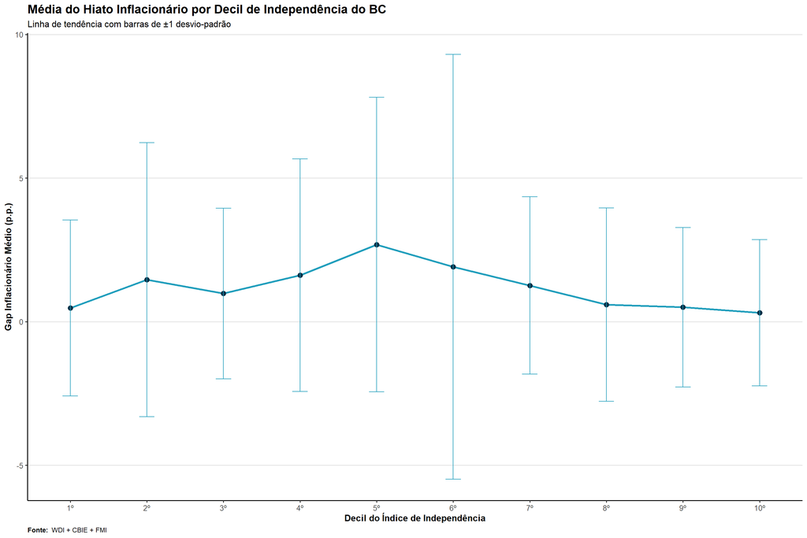

```r
data %>%
  mutate(
    cbie_index = as.numeric(cbie_index),
    gap        = as.numeric(gap)
  ) %>%
  filter(!is.na(cbie_index), !is.na(gap)) %>%
  mutate(decil = ntile(cbie_index, 10)) %>%
  group_by(decil) %>%
  summarise(
    mean_gap = mean(gap),
    sd_gap   = sd(gap),
    .groups  = "drop"
  ) %>%
  ggplot(aes(x = decil, y = mean_gap)) +
  geom_line(color = "#219ebc", size = 1.2) +
  geom_point(color = "#023047", size = 3) +
  geom_errorbar(
    aes(ymin = mean_gap - sd_gap, ymax = mean_gap + sd_gap),
    width = 0.2, color = "#219ebc"
  ) +
  scale_x_continuous(
    breaks = 1:10,
    labels = paste0(1:10, "º")
  ) +
  labs(
    title    = "Média do Hiato Inflacionário por Decil de Independência do BC",
    subtitle = "Linha de tendência com barras de ±1 desvio-padrão",
    x        = "Decil do Índice de Independência",
    y        = "Gap Inflacionário Médio (p.p.)",
    caption  = expression(bold("Fonte: ") ~ "WDI + CBIE + FMI")
  ) +
  theme_classic(base_size = 12) +
  theme(
    axis.title        = element_text(face = "bold"),
    axis.text         = element_text(size = 10),
    plot.title        = element_text(face = "bold", size = 16, hjust = 0),
    plot.subtitle     = element_text(size = 12, hjust = 0, margin = margin(b = 6)),
    plot.caption      = element_text(size = 9, hjust = 0, color = "black"),
    panel.grid.major.y = element_line(color = "grey90"),
    panel.grid.major.x = element_blank()
  )
```

## 9.5 📊 Gráfico da Evolução do CBI

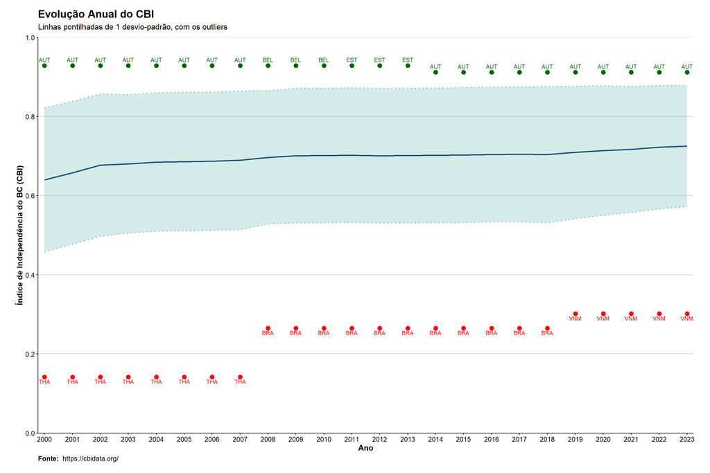

```r
ggplot() +
  geom_ribbon(
    data = data %>%
      group_by(year) %>%
      summarise(
        mean_cbie = mean(cbie_index, na.rm = TRUE),
        sd_cbie   = sd(cbie_index, na.rm = TRUE)
      ),
    aes(
      x = year,
      ymin = mean_cbie - sd_cbie,
      ymax = mean_cbie + sd_cbie
    ),
    fill = "#2A9D8F",
    alpha = 0.2
  ) +
  geom_line(
    data = data %>%
      group_by(year) %>%
      summarise(mean_cbie = mean(cbie_index, na.rm = TRUE)),
    aes(x = year, y = mean_cbie),
    color = "#1F4E79",
    size = 1
  ) +
  geom_line(
    data = data %>%
      group_by(year) %>%
      summarise(
        mean_cbie = mean(cbie_index, na.rm = TRUE),
        sd_cbie   = sd(cbie_index, na.rm = TRUE)
      ),
    aes(x = year, y = mean_cbie + sd_cbie),
    color = "#81B1D6",
    linetype = "dotted",
    size = 0.8
  ) +
  geom_line(
    data = data %>%
      group_by(year) %>%
      summarise(
        mean_cbie = mean(cbie_index, na.rm = TRUE),
        sd_cbie   = sd(cbie_index, na.rm = TRUE)
      ),
    aes(x = year, y = mean_cbie - sd_cbie),
    color = "#81B1D6",
    linetype = "dotted",
    size = 0.8
  ) +
  geom_point(
    data = data %>%
      group_by(year) %>%
      mutate(
        mean_cbie   = mean(cbie_index, na.rm = TRUE),
        sd_cbie     = sd(cbie_index, na.rm = TRUE),
        distance_up = cbie_index - (mean_cbie + sd_cbie)
      ) %>%
      filter(cbie_index > mean_cbie + sd_cbie) %>%
      slice_max(distance_up, with_ties = FALSE) %>%
      ungroup(),
    aes(x = year, y = cbie_index),
    color = "darkgreen",
    size = 3
  ) +
  geom_text(
    data = data %>%
      group_by(year) %>%
      mutate(
        mean_cbie   = mean(cbie_index, na.rm = TRUE),
        sd_cbie     = sd(cbie_index, na.rm = TRUE),
        distance_up = cbie_index - (mean_cbie + sd_cbie)
      ) %>%
      filter(cbie_index > mean_cbie + sd_cbie) %>%
      slice_max(distance_up, with_ties = FALSE) %>%
      ungroup(),
    aes(x = year, y = cbie_index, label = iso3c),
    color = "darkgreen",
    vjust = -0.8,
    size = 3
  ) +
  geom_point(
    data = data %>%
      group_by(year) %>%
      mutate(
        mean_cbie     = mean(cbie_index, na.rm = TRUE),
        sd_cbie       = sd(cbie_index, na.rm = TRUE),
        distance_down = (mean_cbie - sd_cbie) - cbie_index
      ) %>%
      filter(cbie_index < mean_cbie - sd_cbie) %>%
      slice_max(distance_down, with_ties = FALSE) %>%
      ungroup(),
    aes(x = year, y = cbie_index),
    color = "red",
    size = 3
  ) +
  geom_text(
    data = data %>%
      group_by(year) %>%
      mutate(
        mean_cbie     = mean(cbie_index, na.rm = TRUE),
        sd_cbie       = sd(cbie_index, na.rm = TRUE),
        distance_down = (mean_cbie - sd_cbie) - cbie_index
      ) %>%
      filter(cbie_index < mean_cbie - sd_cbie) %>%
      slice_max(distance_down, with_ties = FALSE) %>%
      ungroup(),
    aes(x = year, y = cbie_index, label = iso3c),
    color = "red",
    vjust = 1.5,
    size = 3
  ) +
  scale_x_continuous(breaks = sort(unique(data$year)), expand = expansion(mult = c(0.01, 0.01))) +
  scale_y_continuous(
    limits = c(0, 1),
    breaks = seq(0, 1, 0.2),
    expand = expansion(mult = c(0, 0))
  ) +
  labs(
    title    = "Evolução Anual do CBI",
    subtitle = "Linhas pontilhadas de 1 desvio-padrão, com os outliers",
    x        = "Ano",
    y        = "Índice de Independência do BC (CBI)",
    caption  = expression(bold("Fonte: ") ~ "https://cbidata.org/")
  ) +
  theme(
    plot.background    = element_rect(fill = "white", color = NA),
    panel.background   = element_rect(fill = "white", color = NA),
    panel.grid.major.y = element_line(color = "grey80"),
    panel.grid.major.x = element_blank(),
    panel.grid.minor   = element_blank(),
    axis.line.x.bottom = element_line(color = "black"),
    axis.line.y.left   = element_line(color = "black"),
    axis.ticks         = element_line(color = "black"),
    plot.title         = element_text(face = "bold", size = 16, hjust = 0),
    plot.subtitle      = element_text(
      size = 12,
      hjust = 0,
      margin = margin(b = 10)
    ),
    axis.title         = element_text(face = "bold", size = 12),
    axis.text          = element_text(size = 10, color = "black"),
    plot.caption       = element_text(
      hjust = 0,
      size = 10,
      color = "black"
    ),
    plot.margin        = margin(15, 25, 15, 25)
  )
```

## 9.6 📊 Gráfico da Evolução da Variáveis

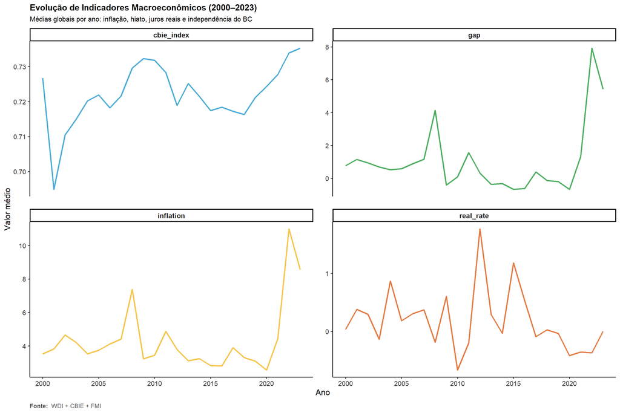

```r
data %>%
  select(year, cbie_index, inflation, real_rate, gap) %>%
  filter(across(everything(), ~ !is.na(.))) %>%
  group_by(year) %>%
  summarise(across(c(cbie_index, inflation, real_rate, gap), ~ mean(.x, na.rm = TRUE)), .groups = "drop") %>%
  pivot_longer(cols = -year, names_to = "variavel", values_to = "valor") %>%
  ggplot(aes(x = year, y = valor, color = variavel)) +
  geom_line(size = 1.2) +
  facet_wrap(~ variavel, scales = "free_y", ncol = 2, strip.position = "top") +
  scale_color_manual(values = c(
    "cbie_index" = "#4DACD6",
    "gap"        = "#4FAE62",
    "inflation"  = "#F6C54D",
    "real_rate"  = "#E37D46"
  )) +
  labs(
    title    = "Evolução de Indicadores Macroeconômicos (2000–2023)",
    subtitle = "Médias globais por ano: inflação, hiato, juros reais e independência do BC",
    x        = "Ano",
    y        = "Valor médio",
    caption  = expression(bold("Fonte:") ~ " WDI + CBIE + FMI")
  ) +
  theme_classic(base_size = 14) +
  theme(
    plot.title      = element_text(face = "bold", size = 15),
    plot.subtitle   = element_text(size = 12, margin = margin(b = 10)),
    strip.text      = element_text(face = "bold", size = 12),
    panel.spacing   = unit(1.5, "lines"),
    plot.caption    = element_text(hjust = 0, size = 10, color = "gray30", margin = margin(t = 12)),
    axis.text       = element_text(color = "gray20"),
    legend.position = "none"
  )
```

## 9.7 📊 Gráfico da Volatilidade do Gap de Inflação

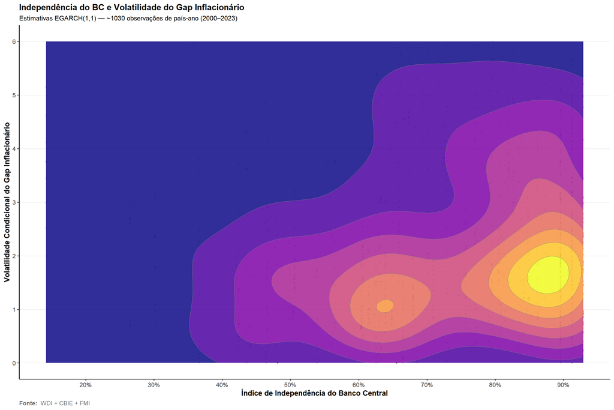

```r
data %>%
  mutate(across(c(year, gap, cbie_index), as.numeric)) %>%
  filter(!is.na(gap), !is.na(cbie_index)) %>%
  filter(n() >= 12, .by = country) %>%
  group_by(country) %>%
  arrange(year, .by_group = TRUE) %>%
  nest() %>%
  mutate(
    garch_out = map(data, ~{
      spec <- ugarchspec(
        variance.model = list(
          model      = "eGARCH",
          garchOrder = c(1, 1)
        ),
        mean.model     = list(armaOrder = c(0, 0)),
        distribution.model = "std"
      )

      fit <- tryCatch(
        ugarchfit(spec, data = .x$gap, solver = "hybrid"),
        error = function(e) NULL
      )

      if (!is.null(fit)) {
        tibble(
          cbie_index = .x$cbie_index,
          sigma_t    = as.numeric(sigma(fit))
        )
      } else {
        tibble(cbie_index = numeric(0), sigma_t = numeric(0))
      }
    })
  ) %>%
  unnest(garch_out) %>%
  filter(!is.na(sigma_t)) %>%
  ggplot(aes(cbie_index, sigma_t)) +
  geom_point(alpha = .12, size = 1, colour = "#000000") +
  stat_density_2d_filled(contour_var = "density", adjust = 1.2, alpha = 0.85) +
  stat_density_2d(contour_var = "density", adjust = 1.2,
                  size = 0.25, colour = "grey50", show.legend = FALSE) +
  scale_fill_viridis_d(option = "plasma") +
  scale_x_continuous(
    breaks = seq(0.2, 0.9, 0.1),
    labels = scales::label_percent(accuracy = 1),
    name   = "Índice de Independência do Banco Central"
  ) +
  scale_y_continuous(
    limits = c(0, 6),
    breaks = 0:6,
    name   = "Volatilidade Condicional do Gap Inflacionário"
  ) +
  labs(
    title    = "Independência do BC e Volatilidade do Gap Inflacionário",
    subtitle = "Estimativas EGARCH(1,1) — ~1030 observações de país-ano (2000–2023)",
    caption  = expression(bold("Fonte:") ~ " WDI + CBIE + FMI")
  ) +
  theme_classic(base_size = 13) +
  theme(
    plot.title      = element_text(face = "bold", size = 15, hjust = 0),
    plot.subtitle   = element_text(size = 11.5, hjust = 0),
    axis.title      = element_text(face = "bold"),
    axis.text       = element_text(color = "gray20"),
    plot.caption    = element_text(hjust = 0, size = 10, color = "gray40"),
    legend.position = "none",
    panel.grid.major.y = element_line(colour = "grey85", linewidth = 0.3)
  )
```

## 9.8 📊 Gráfico do Gap de Inflação por Independência do BC

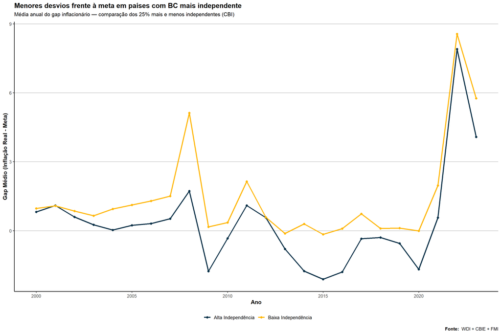

```r
data %>%
  filter(!is.na(gap), !is.na(cbie_index)) %>%
  mutate(
    grupo_indep = if_else(
      cbie_index >= quantile(cbie_index, 0.75, na.rm = TRUE),
      "Alta Independência", "Baixa Independência"
    )
  ) %>%
  group_by(year, grupo_indep) %>%
  summarise(avg_gap = mean(gap), .groups = "drop") %>%
  ggplot(aes(x = year, y = avg_gap, color = grupo_indep)) +
  geom_line(size = 1.2) +
  geom_point(size = 2) +
  scale_color_manual(
    values = c("Alta Independência" = "#023047", "Baixa Independência" = "#ffb703"),
    name = ""
  ) +
  labs(
    title    = "Menores desvios frente à meta em países com BC mais independente",
    subtitle = "Média anual do gap inflacionário — comparação dos 25% mais e menos independentes (CBI)",
    x        = "Ano",
    y        = "Gap Médio (Inflação Real - Meta)",
    caption  = expression(bold("Fonte: ") ~ "WDI + CBIE + FMI")
  ) +
  theme_classic(base_size = 12) +
  theme(
    plot.title         = element_text(face = "bold", size = 15, hjust = 0),
    plot.subtitle      = element_text(size = 11.5, hjust = 0, margin = margin(b = 10)),
    legend.position    = "bottom",
    legend.text        = element_text(size = 10),
    panel.grid.major.y = element_line(color = "grey80"),
    axis.title         = element_text(face = "bold")
  )
```

## 9.9 📊 Gráfico do Hiato de Produto e Inflação

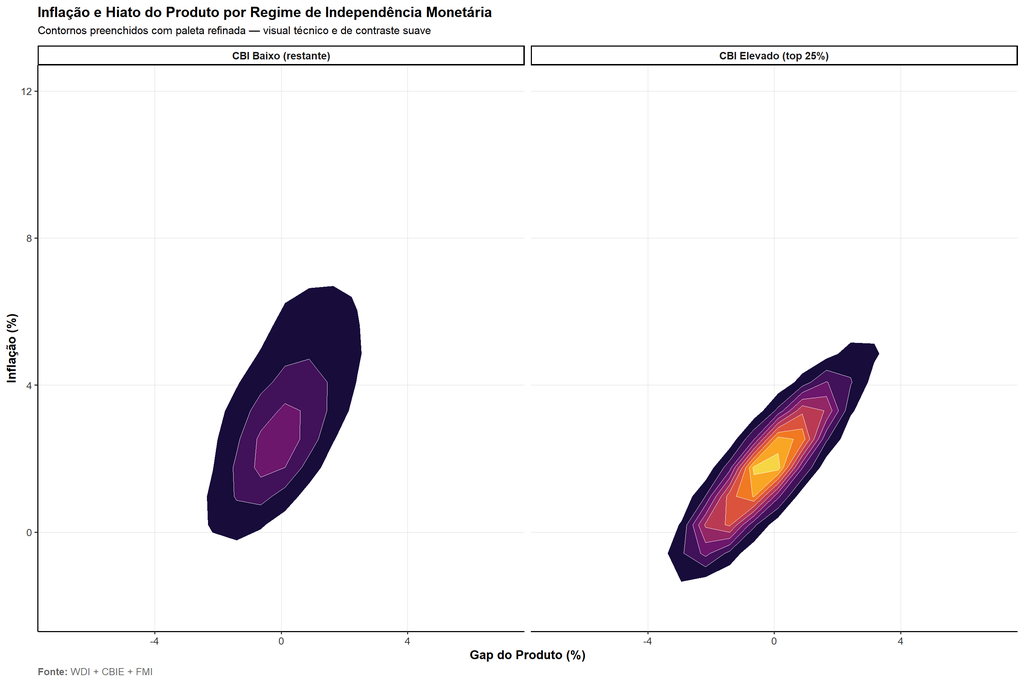

```r
data %>%
  filter(!is.na(inflation), !is.na(gap), !is.na(cbie_index)) %>%
  mutate(
    grupo_indep = if_else(
      cbie_index >= quantile(cbie_index, 0.75, na.rm = TRUE),
      "CBI Elevado (top 25%)", "CBI Baixo (restante)"
    )
  ) %>%
  ggplot(aes(x = gap, y = inflation)) +
  stat_density_2d(
    aes(fill = after_stat(level)),
    geom = "polygon",
    bins = 10,
    color = "white",
    linewidth = 0.3
  ) +
  facet_wrap(~ grupo_indep) +
  coord_cartesian(xlim = c(-7, 7), ylim = c(-2, 12)) +
  scale_fill_viridis_c(
    option = "inferno",
    direction = 1,
    begin = 0.1,
    end = 0.9,
    guide = "none",
    na.value = NA
  ) +
  labs(
    title    = "Inflação e Hiato do Produto por Regime de Independência Monetária",
    subtitle = "Contornos preenchidos com paleta refinada — visual técnico e de contraste suave",
    x        = "Gap do Produto (%)",
    y        = "Inflação (%)",
    caption  = expression(bold("Fonte:") ~ "WDI + CBIE + FMI")
  ) +
  theme_classic(base_size = 13) +
  theme(
    plot.title       = element_text(face = "bold", size = 15, hjust = 0),
    plot.subtitle    = element_text(size = 11.5, hjust = 0, margin = margin(b = 10)),
    strip.text       = element_text(face = "bold", size = 11),
    axis.title       = element_text(face = "bold"),
    axis.text        = element_text(color = "gray20"),
    panel.grid.major = element_line(color = "grey85", linewidth = 0.3),
    plot.caption     = element_text(hjust = 0, size = 10, color = "gray40"),
    legend.position  = "none"
  )
```

## 9.10 📊 Gráfico da Mudança no CBI e Inflação

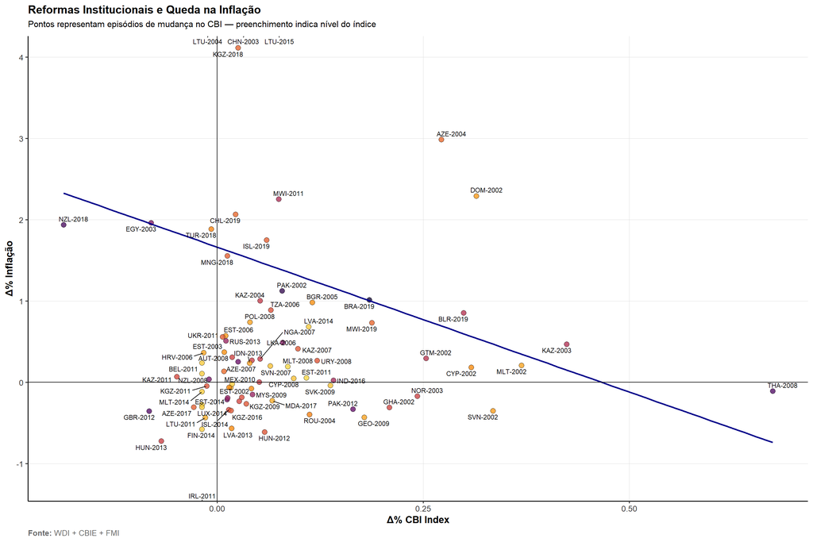

```r
data %>%
  group_by(country) %>%
  mutate(
    change_inflation = (
      (
        (inflation + dplyr::lead(inflation, 1) + dplyr::lead(inflation, 2) +
           dplyr::lead(inflation, 3) + dplyr::lead(inflation, 4)) /4
      ) /
        ((inflation + dplyr::lag(inflation, 1) + dplyr::lag(inflation, 2)) / 3) - 1
    ),
    cbie_change = (cbie_index - dplyr::lag(cbie_index, 1)) / cbie_index
  ) %>%
  filter(!is.na(change_inflation), !is.na(cbie_change), cbie_change != 0) %>%
  ggplot(aes(x = cbie_change, y = change_inflation)) +
  geom_point(
    aes(fill = cbie_index),
    alpha = 0.8,
    shape = 21,
    size = 3,
    color = "black"
  ) +
  geom_smooth(method = "lm", se = FALSE, fullrange = TRUE, color = "darkblue", linewidth = 1) +
  geom_hline(yintercept = 0, linetype = "solid", color = "black") +
  geom_vline(xintercept = 0, linetype = "solid", color = "black") +
  geom_text_repel(aes(label = paste(iso3c, year, sep = "-")), size = 3, max.overlaps = 10) +

  coord_cartesian(ylim = c(-1.2, 4)) +
  scale_fill_viridis_c(
    option = "inferno",
    direction = 1,
    begin = 0.1,
    end = 0.9,
    guide = "none",
    na.value = NA
  ) +
  labs(
    title    = "Reformas Institucionais e Queda na Inflação",
    subtitle = "Pontos representam episódios de mudança no CBI — preenchimento indica nível do índice",
    x        = "\u0394% CBI Index",
    y        = "\u0394% Inflação",
    caption  = expression(bold("Fonte:") ~ "WDI + CBIE + FMI")
  ) +
  theme_classic(base_size = 13) +
  theme(
    plot.title       = element_text(face = "bold", size = 15, hjust = 0),
    plot.subtitle    = element_text(size = 11.5, hjust = 0, margin = margin(b = 10)),
    axis.title       = element_text(face = "bold"),
    axis.text        = element_text(color = "gray20"),
    panel.grid.major = element_line(color = "grey85", linewidth = 0.3),
    plot.caption     = element_text(hjust = 0, size = 10, color = "gray40"),
    legend.position  = "none"
  )
```

# 10 📈🧮 Estimação do Modelo GMM

## 10.1 🧮 Preparando os Dados

```r
panel <- data %>%
  pdata.frame(index = c("iso3c", "year"))
```

## 10.2 🧮 GMM usando “inflation_gap” como variável dependente

```r
gmm_model_cbie_index <- pgmm(
  formula = gap ~
    lag(gap, 1) +
    cbie_index +
    lag(hiato_pct, 1) +
    inflation_forecast +
    real_rate +
    I(cbie_index * real_rate)
  |
    lag(gap, 3:4) +
    lag(real_rate, 2:3) +
    lag(inflation_forecast, 3:4) +
    lag(hiato_pct, 3:4),
  data           = panel,
  effect         = "individual",
  model          = "twosteps",
  transformation = "ld"
)


summary(gmm_model_cbie_index)
```

```
## Oneway (individual) effect Two-steps model System GMM
##
## Call:
## pgmm(formula = gap ~ lag(gap, 1) + cbie_index + lag(hiato_pct,
##     1) + inflation_forecast + real_rate + I(cbie_index * real_rate) |
##     lag(gap, 3:4) + lag(real_rate, 2:3) + lag(inflation_forecast,
##         3:4) + lag(hiato_pct, 3:4), data = panel, effect = "individual",
##     model = "twosteps", transformation = "ld")
##
## Unbalanced Panel: n = 78, T = 21-24, N = 1869
##
## Number of Observations Used: 2286
## Residuals:
##      Min.   1st Qu.    Median      Mean   3rd Qu.      Max.
## -29.83748  -0.32901   0.00000  -0.03026   0.42721  30.62138
##
## Coefficients:
##                            Estimate Std. Error z-value  Pr(>|z|)
## lag(gap, 1)                0.210451   0.072329  2.9096  0.003619 **
## cbie_index                -2.569861   0.262255 -9.7991 < 2.2e-16 ***
## lag(hiato_pct, 1)          0.182393   0.056438  3.2317  0.001230 **
## inflation_forecast         0.692036   0.049730 13.9160 < 2.2e-16 ***
## real_rate                 -0.629824   0.220015 -2.8626  0.004201 **
## I(cbie_index * real_rate)  0.689214   0.260171  2.6491  0.008071 **
## ---
## Signif. codes:  0 '***' 0.001 '**' 0.01 '*' 0.05 '.' 0.1 ' ' 1
##
## Sargan test: chisq(255) = 62.9242 (p-value = 1)
## Autocorrelation test (1): normal = -2.235449 (p-value = 0.025388)
## Autocorrelation test (2): normal = 1.229819 (p-value = 0.21876)
## Wald test for coefficients: chisq(6) = 1348.853 (p-value = < 2.22e-16)
```

### 10.2.1 🧮 Análise de Robustez

### 10.2.2 🧮 GMM com Impulso Fiscal

```r
gmm_model_cbie_index_fiscal <- pgmm(
  formula = gap ~
    lag(gap, 1) +
    cbie_index +
    lag(hiato_pct, 1) +
    inflation_forecast +
    real_rate +
    impulso_fiscal +
    I(cbie_index * real_rate)
  |
    lag(impulso_fiscal, 1:2) +
    lag(gap, 3:4) +
    lag(real_rate, 2:3) +
    lag(inflation_forecast, 3:4) +
    lag(hiato_pct, 3:4),
  data           = panel,
  effect         = "individual",
  model          = "twosteps",
  transformation = "ld"
)

summary(gmm_model_cbie_index_fiscal)
```

```
## Oneway (individual) effect Two-steps model System GMM
##
## Call:
## pgmm(formula = gap ~ lag(gap, 1) + cbie_index + lag(hiato_pct,
##     1) + inflation_forecast + real_rate + impulso_fiscal + I(cbie_index *
##     real_rate) | lag(impulso_fiscal, 1:2) + lag(gap, 3:4) + lag(real_rate,
##     2:3) + lag(inflation_forecast, 3:4) + lag(hiato_pct, 3:4),
##     data = panel, effect = "individual", model = "twosteps",
##     transformation = "ld")
##
## Unbalanced Panel: n = 78, T = 21-24, N = 1869
##
## Number of Observations Used: 2276
## Residuals:
##      Min.   1st Qu.    Median      Mean   3rd Qu.      Max.
## -29.87359  -0.34414   0.00000  -0.03347   0.40353  30.86674
##
## Coefficients:
##                            Estimate Std. Error z-value  Pr(>|z|)
## lag(gap, 1)                0.220126   0.067769  3.2482  0.001162 **
## cbie_index                -2.429423   0.284789 -8.5306 < 2.2e-16 ***
## lag(hiato_pct, 1)          0.244112   0.062454  3.9087 9.281e-05 ***
## inflation_forecast         0.670147   0.056281 11.9071 < 2.2e-16 ***
## real_rate                 -0.713027   0.282818 -2.5212  0.011697 *
## impulso_fiscal            -0.094536   0.033253 -2.8429  0.004470 **
## I(cbie_index * real_rate)  0.793520   0.340784  2.3285  0.019885 *
## ---
## Signif. codes:  0 '***' 0.001 '**' 0.01 '*' 0.05 '.' 0.1 ' ' 1
##
## Sargan test: chisq(320) = 61.74689 (p-value = 1)
## Autocorrelation test (1): normal = -3.824285 (p-value = 0.00013115)
## Autocorrelation test (2): normal = 2.402408 (p-value = 0.016288)
## Wald test for coefficients: chisq(7) = 1412.487 (p-value = < 2.22e-16)
```

#### 10.2.2.1 🧮 GMM usando CBI(Policy Rate)

```r
gmm_model_cbie_policy <- pgmm(
  formula = gap ~
    lag(gap, 1) +
    cbie_policy +
    lag(hiato_pct, 1) +
    inflation_forecast +
    real_rate +
    impulso_fiscal +
    I(cbie_policy * real_rate)
  |
    lag(impulso_fiscal, 1:2) +
    lag(gap, 3:4) +
    lag(real_rate, 2:3) +
    lag(inflation_forecast, 3:4) +
    lag(hiato_pct, 3:4),
  data           = panel,
  effect         = "individual",
  model          = "twosteps",
  transformation = "ld"
)


summary(gmm_model_cbie_policy)
```

```
## Oneway (individual) effect Two-steps model System GMM
##
## Call:
## pgmm(formula = gap ~ lag(gap, 1) + cbie_policy + lag(hiato_pct,
##     1) + inflation_forecast + real_rate + impulso_fiscal + I(cbie_policy *
##     real_rate) | lag(impulso_fiscal, 1:2) + lag(gap, 3:4) + lag(real_rate,
##     2:3) + lag(inflation_forecast, 3:4) + lag(hiato_pct, 3:4),
##     data = panel, effect = "individual", model = "twosteps",
##     transformation = "ld")
##
## Unbalanced Panel: n = 78, T = 21-24, N = 1869
##
## Number of Observations Used: 2276
## Residuals:
##      Min.   1st Qu.    Median      Mean   3rd Qu.      Max.
## -30.04505  -0.29372   0.00000  -0.03206   0.38533  30.68497
##
## Coefficients:
##                             Estimate Std. Error z-value  Pr(>|z|)
## lag(gap, 1)                 0.220475   0.066097  3.3356 0.0008511 ***
## cbie_policy                -2.903407   0.311084 -9.3332 < 2.2e-16 ***
## lag(hiato_pct, 1)           0.221598   0.058817  3.7676 0.0001648 ***
## inflation_forecast          0.681540   0.053889 12.6471 < 2.2e-16 ***
## real_rate                  -0.921805   0.353122 -2.6104 0.0090425 **
## impulso_fiscal             -0.071265   0.034771 -2.0495 0.0404085 *
## I(cbie_policy * real_rate)  1.119613   0.448737  2.4950 0.0125945 *
## ---
## Signif. codes:  0 '***' 0.001 '**' 0.01 '*' 0.05 '.' 0.1 ' ' 1
##
## Sargan test: chisq(320) = 61.25059 (p-value = 1)
## Autocorrelation test (1): normal = -2.782349 (p-value = 0.0053967)
## Autocorrelation test (2): normal = 1.570402 (p-value = 0.11632)
## Wald test for coefficients: chisq(7) = 1412.972 (p-value = < 2.22e-16)
```

### 10.2.3 🧮 GMM usando CBI(Policy Rate-Q1)

```r
gmm_model_cbie_policy_q1 <- pgmm(
  formula = gap ~
    lag(gap, 1) +
    cbie_policy_q1 +
    real_rate +
    lag(hiato_pct, 1) +
    inflation_forecast +
    impulso_fiscal +
    I(cbie_policy_q1 * real_rate)

  |
    lag(impulso_fiscal, 1:2) +
    lag(gap, 3:4) +
    lag(real_rate, 2:3) +
    lag(inflation_forecast, 3:4) +
    lag(hiato_pct, 3:4),
  data           = panel,
  effect         = "individual",
  model          = "twosteps",
  transformation = "ld"
)

summary(gmm_model_cbie_policy_q1)
```

```
## Oneway (individual) effect Two-steps model System GMM
##
## Call:
## pgmm(formula = gap ~ lag(gap, 1) + cbie_policy_q1 + real_rate +
##     lag(hiato_pct, 1) + inflation_forecast + impulso_fiscal +
##     I(cbie_policy_q1 * real_rate) | lag(impulso_fiscal, 1:2) +
##     lag(gap, 3:4) + lag(real_rate, 2:3) + lag(inflation_forecast,
##     3:4) + lag(hiato_pct, 3:4), data = panel, effect = "individual",
##     model = "twosteps", transformation = "ld")
##
## Unbalanced Panel: n = 78, T = 21-24, N = 1869
##
## Number of Observations Used: 2276
## Residuals:
##      Min.   1st Qu.    Median      Mean   3rd Qu.      Max.
## -30.32972  -0.31292   0.00000  -0.01598   0.42570  30.72643
##
## Coefficients:
##                                Estimate Std. Error z-value  Pr(>|z|)
## lag(gap, 1)                    0.228248   0.067508  3.3811  0.000722 ***
## cbie_policy_q1                -2.067270   0.221482 -9.3338 < 2.2e-16 ***
## real_rate                     -1.304038   0.701606 -1.8586  0.063077 .
## lag(hiato_pct, 1)              0.234592   0.058907  3.9824 6.822e-05 ***
## inflation_forecast             0.675421   0.050591 13.3505 < 2.2e-16 ***
## impulso_fiscal                -0.093326   0.031400 -2.9722  0.002957 **
## I(cbie_policy_q1 * real_rate)  1.256402   0.707274  1.7764  0.075667 .
## ---
## Signif. codes:  0 '***' 0.001 '**' 0.01 '*' 0.05 '.' 0.1 ' ' 1
##
## Sargan test: chisq(320) = 61.17685 (p-value = 1)
## Autocorrelation test (1): normal = -2.446639 (p-value = 0.01442)
## Autocorrelation test (2): normal = 1.54667 (p-value = 0.12194)
## Wald test for coefficients: chisq(7) = 1563.529 (p-value = < 2.22e-16)
```

## 10.3 🧮 Resultados com estimativas e erros padrão

```r
create_gmm_table <- function(gmm_model, title, data, panel) {
  s   <- summary(gmm_model, robust = TRUE)
  cm  <- as_tibble(s$coefficients, rownames = "term")

  # Coluna de p‑valor (primeira cujo nome começa com "Pr")
  pcol <- grep("^Pr", colnames(cm), value = TRUE)[1]

  mapping <- tribble(
    ~term,                          ~Parametro,
    "I(cbie_index * real_rate)",    "α₁ (Independência do BC × Taxa Real de Juros)",
    "I(cbie_policy * real_rate)",   "α₁ (Independência do BC (PM) × Taxa Real de Juros)",
    "I(cbie_policy_q1 * real_rate)","α₁ (Independência do BC (PM Q1) × Taxa Real de Juros)",
    "lag(gap, 1)",                  "α₂ (Gap de Inflação Defasado)",
    "lag(hiato_pct, 1)",            "α₃ (Hiato do Produto Defasado)",
    "inflation_forecast",           "α₄ (Expectativa de Inflação)",
    "cbie_index",                   "α₅ (Índice de Independência do BC)",
    "cbie_policy",                  "α₅ (Índice de Independência do BC - Política Monetária)",
    "cbie_policy_q1",               "α₅ (Índice de Independência do BC - Política Monetária Q1)",
    "real_rate",                    "α₆ (Taxa Real de Juros)",
    "impulso_fiscal",               "α₇ (Impulso Fiscal)"
  )

  res <- cm %>%
    left_join(mapping, by = "term") %>%
    mutate(
      Parametro = coalesce(Parametro, term),
      Resultado = paste0(
        sprintf("%.4f", Estimate),
        case_when(
          .data[[pcol]] < 0.001 ~ "***",
          .data[[pcol]] < 0.01  ~ "**",
          .data[[pcol]] < 0.05  ~ "*",
          TRUE                  ~ ""
        ),
        "<br/>(",
        sprintf("%.4f", `Std. Error`),
        ")"
      )
    ) %>%
    arrange(match(Parametro, c(
      "α₁ (Independência do BC × Taxa Real de Juros)",
      "α₁ (Independência do BC (PM) × Taxa Real de Juros)",
      "α₁ (Independência do BC (PM Q1) × Taxa Real de Juros)",
      "α₂ (Gap de Inflação Defasado)",
      "α₃ (Hiato do Produto Defasado)",
      "α₄ (Expectativa de Inflação)",
      "α₅ (Índice de Independência do BC)",
      "α₅ (Índice de Independência do BC - Política Monetária)",
      "α₅ (Índice de Independência do BC - Política Monetária Q1)",
      "α₆ (Taxa Real de Juros)",
      "α₇ (Impulso Fiscal)"
    ))) %>%
    select(Parâmetro = Parametro, Resultado)

  # Estatísticas complementares
  sg  <- sargan(gmm_model, robust = TRUE)
  ar1 <- mtest(gmm_model, 1)
  ar2 <- mtest(gmm_model, 2)
  coefs <- coef(gmm_model)
  Vrob  <- vcov(gmm_model, robust = TRUE)
  wald_stat <- as.numeric(t(coefs) %*% solve(Vrob) %*% coefs)
  wald_df   <- length(coefs)
  wald_p    <- pchisq(wald_stat, wald_df, lower.tail = FALSE)

  n_countries <- length(unique(data$iso3c))
  n_obs       <- nrow(panel)

  res %>%
    gt() %>%
    tab_header(title) %>%
    fmt_markdown(columns = "Resultado") %>%
    tab_source_note(md(glue("Países (n): {n_countries}  •  Observações (N): {n_obs}"))) %>%
    tab_source_note(md("Significância: *** p<0.001; ** p<0.01; * p<0.05")) %>%
    tab_source_note(md(glue("Sargan: χ²({sg$df}) = {round(sg$statistic,3)} (p = {round(sg$p.value,3)})"))) %>%
    tab_source_note(md(glue("Wald: χ²({wald_df}) = {round(wald_stat,3)} (p = {format.pval(wald_p,3)})"))) %>%
    tab_source_note(md(glue("AR(1): z = {round(ar1$statistic,3)} (p = {round(ar1$p.value,3)})"))) %>%
    tab_source_note(md(glue("AR(2): z = {round(ar2$statistic,3)} (p = {round(ar2$p.value,3)})")))
}


table_cbie_index <- create_gmm_table(
  gmm_model_cbie_index,
  "Estimativas GMM — Índice de Independência do BC",
  data,
  panel
)

table_cbie_index_fiscal <- create_gmm_table(
  gmm_model_cbie_index_fiscal,
  "Estimativas GMM — Índice de Independência do BC (Fiscal)",
  data,
  panel
)

table_cbie_policy <- create_gmm_table(
  gmm_model_cbie_policy,
  "Estimativas GMM — Independência do BC (Política Monetária)",
  data,
  panel
)

table_cbie_policy_q1 <- create_gmm_table(
  gmm_model_cbie_policy_q1,
  "Estimativas GMM — Independência do BC (Política Monetária Q1)",
  data,
  panel
)

# Exibir as tabelas
table_cbie_index
```

Estimativas GMM — Índice de Independência do BC

| Parâmetro | Resultado |
| --- | --- |
| α₁ (Independência do BC × Taxa Real de Juros) | 0.6892** (0.2602) |
| α₂ (Gap de Inflação Defasado) | 0.2105** (0.0723) |
| α₃ (Hiato do Produto Defasado) | 0.1824** (0.0564) |
| α₄ (Expectativa de Inflação) | 0.6920*** (0.0497) |
| α₅ (Índice de Independência do BC) | -2.5699*** (0.2623) |
| α₆ (Taxa Real de Juros) | -0.6298** (0.2200) |

Países (n): 78 • Observações (N): 1869  
Significância: *** p<0.001; ** p<0.01; * p<0.05  
Wald: χ²(6) = 51803.945 (p = <2e-16)  
AR(1): z = -2.306 (p = 0.021)  
AR(2): z = 1.381 (p = 0.167)

```r
table_cbie_index_fiscal
```

Estimativas GMM — Índice de Independência do BC (Fiscal)

| Parâmetro | Resultado |
| --- | --- |
| α₁ (Independência do BC × Taxa Real de Juros) | 0.7935* (0.3408) |
| α₂ (Gap de Inflação Defasado) | 0.2201** (0.0678) |
| α₃ (Hiato do Produto Defasado) | 0.2441*** (0.0625) |
| α₄ (Expectativa de Inflação) | 0.6701*** (0.0563) |
| α₅ (Índice de Independência do BC) | -2.4294*** (0.2848) |
| α₆ (Taxa Real de Juros) | -0.7130* (0.2828) |
| α₇ (Impulso Fiscal) | -0.0945** (0.0333) |

```r
table_cbie_policy
```

Estimativas GMM — Independência do BC (Política Monetária)

| Parâmetro | Resultado |
| --- | --- |
| α₁ (Independência do BC (PM) × Taxa Real de Juros) | 1.1196* (0.4487) |
| α₂ (Gap de Inflação Defasado) | 0.2205*** (0.0661) |
| α₃ (Hiato do Produto Defasado) | 0.2216*** (0.0588) |
| α₄ (Expectativa de Inflação) | 0.6815*** (0.0539) |
| α₅ (Índice de Independência do BC - Política Monetária) | -2.9034*** (0.3111) |
| α₆ (Taxa Real de Juros) | -0.9218** (0.3531) |
| α₇ (Impulso Fiscal) | -0.0713* (0.0348) |

Países (n): 78 • Observações (N): 1869  
Significância: *** p<0.001; ** p<0.01; * p<0.05  
Wald: χ²(7) = 72315.01 (p = <2e-16)  
AR(1): z = -2.896 (p = 0.004)  
AR(2): z = 1.964 (p = 0.049)

```r
table_cbie_policy_q1
```

Estimativas GMM — Independência do BC (Política Monetária Q1)

| Parâmetro | Resultado |
| --- | --- |
| α₁ (Independência do BC (PM Q1) × Taxa Real de Juros) | 1.2564 (0.7073) |
| α₂ (Gap de Inflação Defasado) | 0.2282*** (0.0675) |
| α₃ (Hiato do Produto Defasado) | 0.2346*** (0.0589) |
| α₄ (Expectativa de Inflação) | 0.6754*** (0.0506) |
| α₅ (Índice de Independência do BC - Política Monetária Q1) | -2.0673*** (0.2215) |
| α₆ (Taxa Real de Juros) | -1.3040 (0.7016) |
| α₇ (Impulso Fiscal) | -0.0933** (0.0314) |

Países (n): 78 • Observações (N): 1869  
Significância: *** p<0.001; ** p<0.01; * p<0.05  
Wald: χ²(7) = 20374.249 (p = <2e-16)  
AR(1): z = -2.525 (p = 0.012)  
AR(2): z = 1.842 (p = 0.065)

## 10.4 🧮 Gráfico de Efeitos Marginais do Modelo GMM

### 10.4.1 🧮 Coeficientes do Modelo GMM

```r
coefs     <- coef(gmm_model_cbie_index)
coef_real <- coefs["real_rate"]
coef_cbi  <- coefs["cbie_index"]
coef_int  <- coefs["I(cbie_index * real_rate)"]

cbi_levels <- c(round(min(panel$cbie_index),2), 0.5, round(max(panel$cbie_index),2))

rr_levels  <- c(0, 5, 10)
```

### 10.4.2 🧮 Efeitos Marginal Juros Reais

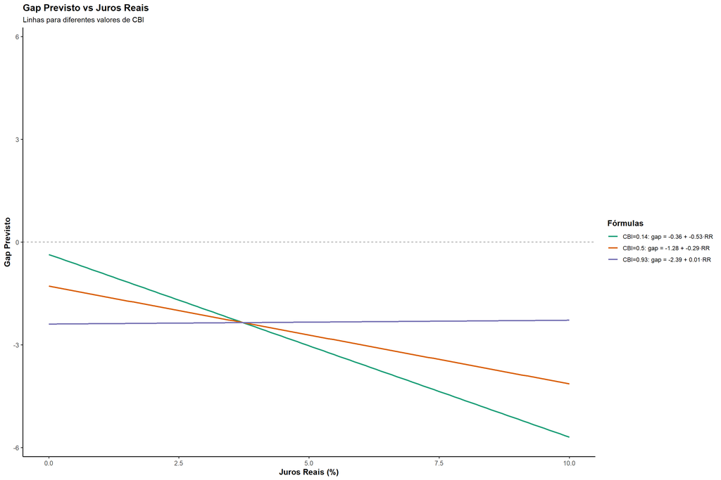

```r
df1 <- expand.grid(
  real_rate  = seq(0, 10, length.out = 100),
  cbie_index = cbi_levels
) %>% mutate(
  gap_hat = coef_cbi * cbie_index +
    coef_real * real_rate +
    coef_int  * cbie_index * real_rate
)

ymax1 <- max(abs(df1$gap_hat))

ggplot(df1, aes(x = real_rate, y = gap_hat, color = factor(cbie_index))) +
  geom_hline(yintercept = 0, linetype = "dashed", color = "grey50") +
  geom_line(size = 1) +
  coord_cartesian(ylim = c(-ymax1, ymax1)) +
  scale_color_brewer(
    type    = "qual", palette = 2,
    labels  = paste0(
      "CBI=", cbi_levels,
      ": gap = ", round(coef_cbi * cbi_levels, 2),
      " + ", round(coef_real + coef_int * cbi_levels, 2), "·RR"
    )
  ) +
  labs(
    title    = "Gap Previsto vs Juros Reais",
    subtitle = "Linhas para diferentes valores de CBI",
    x        = "Juros Reais (%)",
    y        = "Gap Previsto",
    color    = "Fórmulas"
  ) +
  theme_classic(base_size = 12) +
  theme(
    plot.title    = element_text(face = "bold", size = 14, hjust = 0),
    plot.subtitle = element_text(size = 11, hjust = 0),
    axis.title    = element_text(face = "bold"),
    legend.title  = element_text(face = "bold"),
    legend.text   = element_text(size = 9)
  )
```

### 10.4.3 🧮 Efeitos Marginais CBI

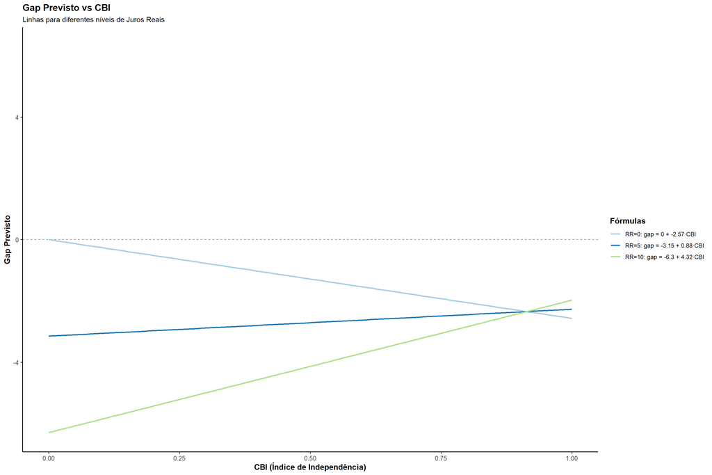

```r
df2 <- expand.grid(
  cbie_index = seq(0, 1, length.out = 100),
  real_rate  = rr_levels
) %>% mutate(
  gap_hat = coef_cbi * cbie_index +
    coef_real * real_rate +
    coef_int  * cbie_index * real_rate
)

ymax2 <- max(abs(df2$gap_hat))

ggplot(df2, aes(x = cbie_index, y = gap_hat, color = factor(real_rate))) +
  geom_hline(yintercept = 0, linetype = "dashed", color = "grey50") +
  geom_line(size = 1) +
  coord_cartesian(ylim = c(-ymax2, ymax2)) +
  scale_color_brewer(
    type    = "qual", palette = 3,
    labels  = paste0(
      "RR=", rr_levels,
      ": gap = ", round(coef_real * rr_levels, 2),
      " + ", round(coef_cbi + coef_int * rr_levels, 2), "·CBI"
    )
  ) +
  labs(
    title    = "Gap Previsto vs CBI",
    subtitle = "Linhas para diferentes níveis de Juros Reais",
    x        = "CBI (Índice de Independência)",
    y        = "Gap Previsto",
    color    = "Fórmulas"
  ) +
  theme_classic(base_size = 12) +
  theme(
    plot.title    = element_text(face = "bold", size = 14, hjust = 0),
    plot.subtitle = element_text(size = 11, hjust = 0),
    axis.title    = element_text(face = "bold"),
    legend.title  = element_text(face = "bold"),
    legend.text   = element_text(size = 9)
  )
```